# Course Project of Practical Machine Learning

### 1. Load the data into r and take a quick look at our dataset. I also split our training data set into two groups for cross validation, called ‘intrain_training’ and ‘intrain_testing’.

```r
setwd('/Users/JohnnyChiu/Desktop/檔案總管/學習/coursera/JohnHopkins-DataScience/Practical Machine Learning/project/')
training<-read.csv('pml-training.csv')
testing<-read.csv('pml-testing.csv')
dim(training)
```

```
## [1] 19622   160
```

```r
dim(testing)
```

```
## [1]  20 160
```

```r
library(caret)
inTrain <- createDataPartition(y=training$classe,p=0.75, list=FALSE)
intrain_training <- training[inTrain,]
intrain_testing <- training[-inTrain,]
```

I will subset some of the elements out, and make every variable into type numeric for model fitting.

```r
library(dplyr)
intrain_training[intrain_training=='']<-NA
sub_intrain_training<-intrain_training[,!is.na(intrain_training[1,])]
sub_intrain_training<-sub_intrain_training[,c(-1,-2)]
dim(sub_intrain_training)
```

```
## [1] 14718    58
```

```r
intrain_testing[intrain_testing=='']<-NA
sub_intrain_testing<-intrain_testing[,!is.na(intrain_testing[1,])]
sub_intrain_testing<-sub_intrain_testing[,c(-1,-2)]
dim(sub_intrain_testing)
```

```
## [1] 4904   58
```

```r
for(i in 1:(dim(sub_intrain_training)[2]-1)){
  sub_intrain_training[,i]<-as.numeric(sub_intrain_training[,i])
}

for(i in 1:(dim(sub_intrain_testing)[2]-1)){
  sub_intrain_testing[,i]<-as.numeric(sub_intrain_testing[,i])
}
```

### 2. Build models on the training dataset

*First, the rpart model*

```r
modFit_rpart <- train(classe ~ .,method="rpart",data=sub_intrain_training)
print(modFit_rpart$finalModel)
```

```
## n= 14718
##
## node), split, n, loss, yval, (yprob)
##       * denotes terminal node
##
##  1) root 14718 10530 A (0.28 0.19 0.17 0.16 0.18)
##    2) roll_belt< 130.5 13486  9310 A (0.31 0.21 0.19 0.18 0.11)
##      4) pitch_forearm< -33.95 1193     5 A (1 0.0042 0 0 0) *
##      5) pitch_forearm>=-33.95 12293  9305 A (0.24 0.23 0.21 0.2 0.12)
##       10) cvtd_timestamp< 2.5 1106   250 A (0.77 0.23 0 0 0) *
##       11) cvtd_timestamp>=2.5 11187  8594 B (0.19 0.23 0.23 0.22 0.13)
##         22) magnet_dumbbell_z< -24.5 4144  2603 A (0.37 0.28 0.091 0.2 0.052) *
##         23) magnet_dumbbell_z>=-24.5 7043  4853 C (0.084 0.2 0.31 0.22 0.18)
##           46) raw_timestamp_part_1< 1.322e+09 410     0 A (1 0 0 0 0) *
##           47) raw_timestamp_part_1>=1.322e+09 6633  4443 C (0.027 0.21 0.33 0.24 0.19)
##             94) magnet_dumbbell_x< -446.5 4603  2545 C (0.031 0.14 0.45 0.27 0.12) *
##             95) magnet_dumbbell_x>=-446.5 2030  1227 B (0.02 0.4 0.065 0.17 0.35) *
##    3) roll_belt>=130.5 1232     9 E (0.0073 0 0 0 0.99) *
```

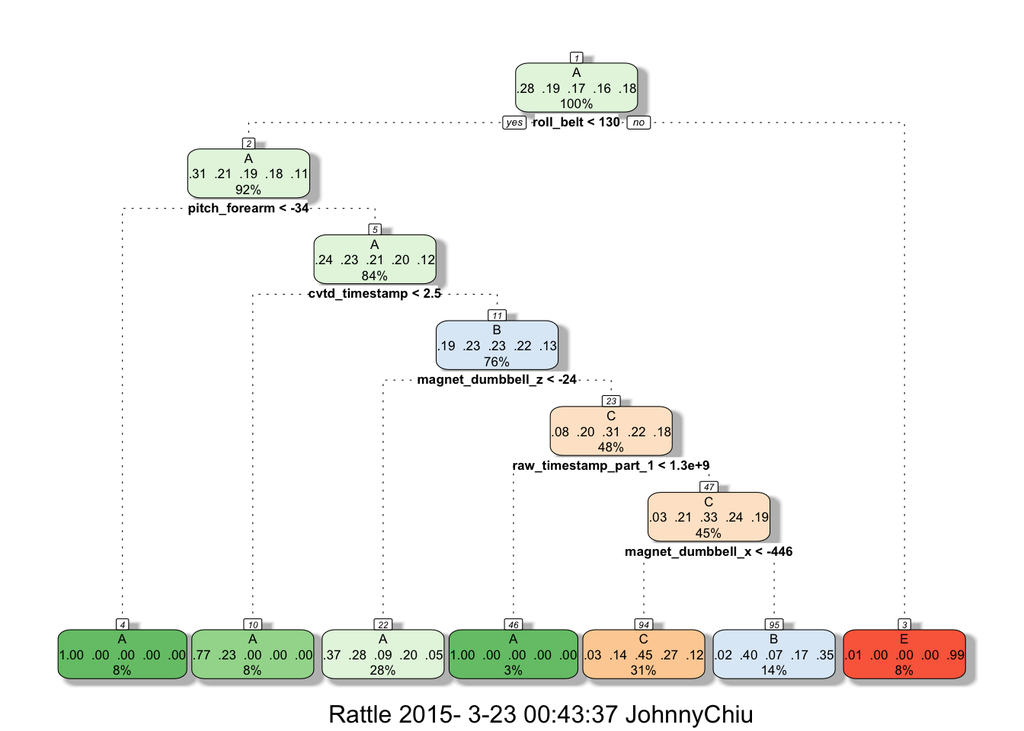

```r
library(rattle)
fancyRpartPlot(modFit_rpart$finalModel)
```

```r
head(predict(modFit_rpart,newdata=sub_intrain_testing))
```

```
## [1] A A A A A A
## Levels: A B C D E
```

```r
confusionMatrix(sub_intrain_testing$classe,predict(modFit_rpart,newdata=sub_intrain_testing))
```

```
## Confusion Matrix and Statistics
##
##           Reference
## Prediction    A    B    C    D    E
##          A 1309   28   53    0    5
##          B  508  264  177    0    0
##          C  142   55  658    0    0
##          D  273  109  422    0    0
##          E   71  230  192    0  408
##
## Overall Statistics
##
##                Accuracy : 0.538
##                  95% CI : (0.524, 0.552)
##     No Information Rate : 0.47
##     P-Value [Acc > NIR] : <2e-16
##
##                   Kappa : 0.401
##  Mcnemar's Test P-Value : NA
##
## Statistics by Class:
##
##                      Class: A Class: B Class: C Class: D Class: E
## Sensitivity             0.568   0.3848    0.438       NA   0.9879
## Specificity             0.967   0.8376    0.942    0.836   0.8902
## Pos Pred Value          0.938   0.2782    0.770       NA   0.4528
## Neg Pred Value          0.717   0.8933    0.792       NA   0.9988
## Prevalence              0.470   0.1399    0.306    0.000   0.0842
## Detection Rate          0.267   0.0538    0.134    0.000   0.0832
## Detection Prevalence    0.284   0.1935    0.174    0.164   0.1837
## Balanced Accuracy       0.768   0.6112    0.690       NA   0.9391
```

```r
#table(sub_intrain_testing$classe)
#table(predict(modFit_rpart,newdata=sub_intrain_testing))
```

*Second, the naive bayes model*(the size of modFit turned out to be too large to knit into a html file, so I will comment it out)

```r
#modFit_nb <- train(classe ~ ., data=sub_intrain_training,method="nb")
#predict(modFit_nb,sub_intrain_testing)
#table(predict(modFit_nb,sub_intrain_testing),sub_intrain_testing$classe)
#confusionMatrix(sub_intrain_testing$classe,predict(modFit_nb,newdata=sub_intrain_testing))
```

*Third, the Linear discriminant analysis(lda) model*

```r
modFit_lda <- train(classe ~ ., data=sub_intrain_training,method="lda")
head(predict(modFit_lda,sub_intrain_testing))
```

```
## [1] A A A A A A
## Levels: A B C D E
```

```r
table(predict(modFit_lda,sub_intrain_testing),sub_intrain_testing$classe)
```

```
##
##        A    B    C    D    E
##   A 1284  148   34    5    2
##   B   59  650   99   16   26
##   C   25  118  643   96   44
##   D   26   23   74  654  127
##   E    1   10    5   33  702
```

```r
confusionMatrix(sub_intrain_testing$classe,predict(modFit_lda,newdata=sub_intrain_testing))
```

```
## Confusion Matrix and Statistics
##
##           Reference
## Prediction    A    B    C    D    E
##          A 1284   59   25   26    1
##          B  148  650  118   23   10
##          C   34   99  643   74    5
##          D    5   16   96  654   33
##          E    2   26   44  127  702
##
## Overall Statistics
##
##                Accuracy : 0.802
##                  95% CI : (0.791, 0.813)
##     No Information Rate : 0.3
##     P-Value [Acc > NIR] : <2e-16
##
##                   Kappa : 0.749
##  Mcnemar's Test P-Value : <2e-16
##
## Statistics by Class:
##
##                      Class: A Class: B Class: C Class: D Class: E
## Sensitivity             0.872    0.765    0.694    0.723    0.935
## Specificity             0.968    0.926    0.947    0.963    0.952
## Pos Pred Value          0.920    0.685    0.752    0.813    0.779
## Neg Pred Value          0.946    0.949    0.930    0.939    0.988
## Prevalence              0.300    0.173    0.189    0.184    0.153
## Detection Rate          0.262    0.133    0.131    0.133    0.143
## Detection Prevalence    0.284    0.194    0.174    0.164    0.184
## Balanced Accuracy       0.920    0.845    0.821    0.843    0.943
```

*Fourth, the random forest model.* (it seems it will take very long time to run if I use  
caret package’s method ‘rf’. Therefore, I will use randomForest directly.)

```r
##method1
#it takes too ling to run it.
# modFit_ranforest <- train(classe~ .,data=sub_intrain_training,method="rf",prox=TRUE)
# modFit_ranforest
# getTree(modFit_ranforest$finalModel,k=2)
# pred <- predict(modFit,testing); testing$predRight <- pred==testing$Species
# table(pred,testing$Species)

##method2
library(randomForest)
library(caret)
```

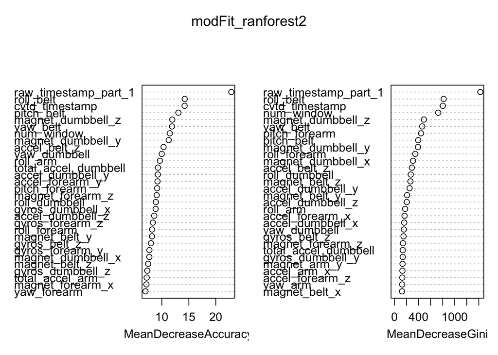

```r
set.seed(415)
modFit_ranforest2 <- randomForest(as.factor(classe) ~ ., data=sub_intrain_training, importance=TRUE, ntree=50)
varImpPlot(modFit_ranforest2)
```

```r
head(predict(modFit_ranforest2, sub_intrain_testing))
```

```
##  6  7 13 17 21 23
##  A  A  A  A  A  A
## Levels: A B C D E
```

```r
confusionMatrix(sub_intrain_testing$classe,predict(modFit_ranforest2,newdata=sub_intrain_testing))
```

```
## Confusion Matrix and Statistics
##
##           Reference
## Prediction    A    B    C    D    E
##          A 1395    0    0    0    0
##          B    0  949    0    0    0
##          C    0    4  850    1    0
##          D    0    0    0  804    0
##          E    0    0    0    0  901
##
## Overall Statistics
##
##                Accuracy : 0.999
##                  95% CI : (0.998, 1)
##     No Information Rate : 0.284
##     P-Value [Acc > NIR] : <2e-16
##
##                   Kappa : 0.999
##  Mcnemar's Test P-Value : NA
##
## Statistics by Class:
##
##                      Class: A Class: B Class: C Class: D Class: E
## Sensitivity             1.000    0.996    1.000    0.999    1.000
## Specificity             1.000    1.000    0.999    1.000    1.000
## Pos Pred Value          1.000    1.000    0.994    1.000    1.000
## Neg Pred Value          1.000    0.999    1.000    1.000    1.000
## Prevalence              0.284    0.194    0.173    0.164    0.184
## Detection Rate          0.284    0.194    0.173    0.164    0.184
## Detection Prevalence    0.284    0.194    0.174    0.164    0.184
## Balanced Accuracy       1.000    0.998    0.999    0.999    1.000
```

*Hence, we choose Random Forest to model our data.*

### 3. Choose the best model from the models that we built, and use the model we fit to predict our testing dataset

```r
testing[testing=='']<-NA
testing<-testing[,!is.na(testing[1,])]
testing<-testing[,c(-1,-2)]
dim(testing)
```

```
## [1] 20 58
```

```r
for(i in 1:(dim(testing)[2]-1)){
  testing[,i]<-as.numeric(testing[,i])
}

predict(modFit_ranforest2, testing)
```

```
##  1  2  3  4  5  6  7  8  9 10 11 12 13 14 15 16 17 18 19 20
##  B  A  B  A  A  E  D  B  A  A  B  C  B  A  E  E  A  B  B  B
## Levels: A B C D E
```

### 4. to generate the file to submit to the coursera website.

```r
answers = c('B','A','B','A','A','E','D','B','A','A','B','C','B','A','E','E','A','B','B','B')

pml_write_files = function(x){
  n = length(x)
  for(i in 1:n){
    filename = paste0("problem_id_",i,".txt")
    write.table(x[i],file=filename,quote=FALSE,row.names=FALSE,col.names=FALSE)
  }
}
pml_write_files(answers)
```